# AMS Data1

## Workshop 4: Tabular data and plotting part 1

###### © 2023, TU Delft. Hans Hoogenboom, Creative Commons

## Introduction

Last week we started with a bit of data processing. We opened a file, tried to find the correct data and then use/manipulate that data for further operations. At the start we experienced already a problem, namely the naming of files on different operating systems (OS, e.g., Linux, Mac and Windows). Windows users had to change the path to the file they wanted to open while Mac users were okay. When exchanging scripts with users of different OS's it is annoying to have to manually change filenames. Even mentioning *manually* means that there is something wrong, we are automating things after all! Luckily for us that Python comes with a library (what a suprise) that can handle this issue for us. Meet **os.path**!

### The os.path library

The *os.path* library comes with Python so there is no need to install it (actually the library is *os* and *path* is a library module, module for short). The module has several functions that can make our lives easier when dealing with files and directories (folders). The functions in *os.path* are not changing anything about the files so they are safe to use.

#### File and filepaths

Files on your computer are categorized (hopefully) in directories. You have a directory where Windows/Mac store all the essential OS files, there is a directory for your pictures etc. Directories and their contents reside on a physical disc (M2, SSD, harddrive, USB). On Windows these are the C: and the D: drives for example. A full path to a file on Windows might read *C:\Users\Hans\Documents\AMS\WS4.ipynb*. *C:* is the drive letter, *\Users\Hans\Documents\AMS\* is the path, *WS4* is the human readable filename and *.ipynb* is the file extension (the file type). Windows often hides the extensions and uses icons to denote filetypes.

#### Absolute and relative paths

When you run a script, you run the script from somewhere, usually from the directory where it is located. This is the current working directory.

```python
import os
# print the current working directory (where am I?)
print(os.getcwd())
```

```
c:\Users\pelle\Downloads
```

If I want to access a file called *data.csv* in say */home/hans/Documents/csv* from my current location I could do that in two ways: by giving the full path */home/hans/Documents/csv/data.csv* which is also named the **absolute path** or by traversing or moving from my current working directory to the new location. Moving from */home/hans/Documents/python* to */home/hans/Documents* is moving up (moving to the left in the path string), from */home/hans/Documents* to */home/hans/Documents/python* is moving down. Moving down is as simple as just specifying the directory name. Moving up is done by using two dots, e.g. "..". So if I am in */home/hans/Documents/python* and I say go to ".." I will end up in */home/hans/Documents*. If I then want to go to the *csv* directory I type *csv*. So ../csv is the **relative path** from my current working directory to */home/hans/Documents/csv*.

If you are in the Windows command prompt or in the shell on Mac, you need to type *cd ..* to move up and *cd name* to move down. Give it a try. The *cd* stand for change directory.

Ok, enough theory and background. So what functions do *os* and *os.path* provide that are useful to us? Below you find some code with comments demonstrating functions from the libraries.

```python
import os
# print the current working directory (where am I?)
cwd = os.getcwd()
# list all contents from the current directory
os.listdir('.')
# and from the directory above
os.listdir('..')
# make a new directory in the current directory
# if you run the code twice you get an error
os.mkdir("my_new_and_silly_dir")

import os.path
# print the absolute path
print(os.path.abspath('.'))
print(os.path.abspath(".."))
print(os.path.abspath("../.."))
# print the name of the current directory
print(os.path.basename(cwd))
# print the path where the current directory or file is located
print(os.path.dirname(cwd))

fake_dir = "answers_to_everything"
# you can join paths like this. Python adds extra \ or /!
new_path = os.path.join(cwd, fake_dir)
print(new_path)
# does a path exist?
print(os.path.exists(new_path))
os.mkdir(new_path)
# now it does!
print(os.path.exists(new_path))
# are we dealing with a file?
print(os.path.isfile(new_path))
current_file = os.path.join(os.getcwd(), "WS4.ipynb")
print(os.path.isfile(current_file))
# get the size of a file
print(os.path.getsize(current_file), "bytes")
```

[output not shown]

Hopefully you have now some functions which can make your life easier when dealing with files on both Windows and Mac.

### individual exercise 1:

Rewrite the above script so you can run it repeatedly.

## Pandas

```python
import pandas as pd
#import plotly as pl
#print(pd.__version__, '\n', pl.__version__, sep='')
```

Pandas can best be compared to Excel. Just as Excel it uses a table, in Pandas a **dataframe**, of rows and columns. A column is called a **series** and can only have one specific datatype (only float or only string etc.). In that sense it is a little more strict then Excel.

If you read through the Pandas documentation you will often see a reference to ndarrays or to Numpy. Ndarrays are n-dimensional arrays (lists) of data and are a data structure from the Numpy library. In a next workshop I will dive in to that library, just to get you familiar with how it works. Something you will appreciate about Pandas is that it can read a lot of different data files by default, have a look at [this list](https://pandas.pydata.org/docs/user_guide/io.html).

You can create your own dataframe with the following function using the *DataFrame* method (take note of the capitals):

```python
df = pd.DataFrame([['AMS', 'Amsterdam', 'Schiphol'], ['LHR', 'London', 'London Heathrow Airport']])
print(df)
```

```
     0          1                        2
0  AMS  Amsterdam                 Schiphol
1  LHR     London  London Heathrow Airport
```

We can add some human readable names to the rows (indices) and columns by directly assigning a list with names.

```python
columns=['IATA', 'City', 'Airport']
df.columns = columns
# or directly assign
df.index = ['a', 'l']
print(df)
```

```
  IATA       City                  Airport
a  AMS  Amsterdam                 Schiphol
l  LHR     London  London Heathrow Airport
```

Getting the data from a colum is pretty much the same as when working with Python dictionaries:

```python
df['IATA']
```

```
a    AMS
l    LHR
Name: IATA, dtype: object
```

But getting data from an index row is a bit different. We need to use the function *loc* here:

```python
df.loc['a']
```

```
IATA             AMS
City       Amsterdam
Airport     Schiphol
Name: a, dtype: object
```

With the *iloc* function you query by a number, so the 1st row:

```python
df.iloc[0]
```

```
IATA             AMS
City       Amsterdam
Airport     Schiphol
Name: a, dtype: object
```

See here for more indexing operations: [Indexing and selecting data](https://pandas.pydata.org/docs/user_guide/indexing.html)

Another example of creating a dataframe, this time with numbers. We initialize the dataframe by a list of numbers. Each row is a seperate list of numbers, all rows are enclosed in square brackets again. That is why you see the [[ at the start and ]] at the end. We can also set the column and row headers directly. You see that the first row of integers gets promoted to floats. A series (column) can have only one data type!

```python
nf = pd.DataFrame([[0, 1, 2], [2.0, 3.0, 4.0], [3.0, 4.0, 5.0]], columns=['2021', '2022', '2023'], index=['area1', 'area2', 'area3'])
nf
```

|  | 2021 | 2022 | 2023 |
| --- | --- | --- | --- |
| area1 | 0.0 | 1.0 | 2.0 |
| area2 | 2.0 | 3.0 | 4.0 |
| area3 | 3.0 | 4.0 | 5.0 |

You can create a single column, a series, using the *Series* function. We can give the series a name and insert it into our datafame using the *insert* method:

```python
ns = pd.Series([3.0, 5.0, 6], name='boring')
print(ns)
nf.insert(2, 'oeap', ns)
nf
```

```
0    3.0
1    5.0
2    6.0
Name: boring, dtype: float64
```

|  | 2021 | 2022 | oeap | 2023 |
| --- | --- | --- | --- | --- |
| area1 | 0.0 | 1.0 | NaN | 2.0 |
| area2 | 2.0 | 3.0 | NaN | 4.0 |
| area3 | 3.0 | 4.0 | NaN | 5.0 |

### individual exercise 2:

1. What happens if you execute the code in the above cell a second time?
2. Change the *insert* statement so that we can insert a new column, do not execute yet! What happens if you change the names of the indices, or remove the *index = ...* altogether, of the **ns** series and you try to insert ns again? Now you can execute the code!

You can set change the values of a cell using the *at* or *iat* function

```python
# use a name based approach
nf.at['area1', '2022'] = 12.1
print(nf, '\n')
# or change by index. Do you see a pattern in the
# naming of the functions loc, iloc, at and iat?
print("Cell at position 1,1:", nf.iat[1, 1])

#print the names of the axes...the index and column names
print(nf.axes)

# find the maximum value of a column
print("Max value in column 2023:", nf['2023'].max())

# find ALL the maximum values in the columns
print("\nColumns:\n", nf.max(axis=0), sep='l')
# and in the rows
print("Rows:\n", nf.max(axis=1), sep='')
# get a single row
sf = nf.loc['area2']
print("\nContents of sf:\n", sf, sep='')
```

```
       2021  2022  oeap  2023
area1   0.0  12.1   NaN   2.0
area2   2.0   3.0   NaN   4.0
area3   3.0   4.0   NaN   5.0

Cell at position 1,1: 3.0
[Index(['area1', 'area2', 'area3'], dtype='object'), Index(['2021', '2022', 'oeap', '2023'], dtype='object')]
Max value in column 2023: 5.0

Columns:
l2021     3.0
2022    12.1
oeap     NaN
2023     5.0
dtype: float64
Rows:
area1    12.1
area2     4.0
area3     5.0
dtype: float64

Contents of sf:
2021    2.0
2022    3.0
oeap    NaN
2023    4.0
Name: area2, dtype: float64
```

What does the *sep* in the print statement do? Change the value and see what happens.

So far we only got a single row or a single value out of our dataframe. How can you select multiple columns and rows at once? One method is by specifying the column names you want to have as a list:

```python
new_frame = nf[['2022', 'leap']]
print(new_frame)
```

[output not shown]

Or we can use the iloc function in combination with slicing. Slicing is a bit similar to a range (well actually it is a range) where we have a start, an end (up to, remember!) and a step. The iloc works on a two dimensional structure, the first part is for rows (indices), the second part for columns:

```python
# slice by columns only
col_b = nf.columns.get_loc('2022')
col_e = nf.columns.get_loc('leap')
new_frame = nf.iloc[: , col_b : col_e]
print(new_frame)

# also slice some rows
new_frame = nf.iloc[1:3 , col_b : col_e + 1]
print(new_frame)
```

[output not shown]

These are some of the basic operations of Pandas. There are many more functions to actually do something with the data like finding the [median](https://pandas.pydata.org/docs/reference/api/pandas.DataFrame.median.html). If you search on Google or use ChatGPT you will find some more examples and methods.

## Plotting

There are many plotting libraries for Python. One of the most well known is [Matplotlib](https://matplotlib.org/). For statistics two nice libraries are [Seaborn](https://seaborn.pydata.org/index.html) and Plotly. For this workshop we will make use of Plotly. Pandas uses Matplotlib by default. You can install Matplotlib with the usual command: *py -m pip install matplotlib*

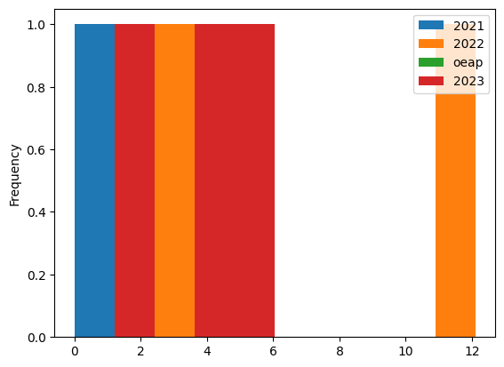

```python
# plot internal
import matplotlib.pyplot as plt
plt.figure()
nf.plot.hist()
```

If we want to use another library for plotting we have to tell Pandas so:

```python
# change default plotting library
pd.options.plotting.backend = "plotly"
fig = nf.plot()
fig.show()
```

[output not shown]

Explore the Plotly website for some basic tutorial on the usage. You can get started [here](https://plotly.com/python/figure-structure/) and [here](https://plotly.com/python/creating-and-updating-figures/).

### Group exercise

On Brightspace you can find under Contents/Resources a long list of datasets. Under the [AirBnB](https://brightspace.wur.nl/d2l/le/content/240321/viewContent/1052192/View) heading you can find a link to a website where you can download the AirBnB data from Amsterdam. Find the average price and the median for the Westerpark neighborhood. Plot the median distribution using Plotly.

## Some useful links

[Pandas 10 min tutorial](https://pandas.pydata.org/docs/user_guide/10min.html)  
[Pandas cookbook](https://pandas.pydata.org/docs/user_guide/cookbook.html)  
[Plotly statistical charts](https://plotly.com/python/statistical-charts/)  
[Numpy](https://numpy.org/)  
[Numpy quickstart](https://numpy.org/devdocs/user/quickstart.html)

### THE END

###### Hans Hoogenboom, Sept. 2023

```python
pip install pandas
```

```python
import pandas as pd
```

```python
df = pd.read_csv('C:/Users/pelle/Downloads/listings.csv')
df.head
```

```
<bound method NDFrame.head of                       id                                               name  \
0                 761411  Condo in Amsterdam · ★4.74 · 1 bedroom · 1 bed...
1                 768274  Rental unit in Amsterdam · ★4.83 · 1 bedroom ·...
2                 768737  Boat in Amsterdam · ★4.82 · 1 bedroom · 1 bed ...
3                 771217  Houseboat in Amsterdam · ★5.0 · 3 bedrooms · 3...
4                 771343  Rental unit in Amsterdam · ★4.89 · 1 bedroom ·...
...                  ...                                                ...
8381  971403658453358540  Rental unit in Amsterdam · ★New · 1 bedroom · ...
8382  971600466535392582  Home in Amsterdam · ★New · 3 bedrooms · 3 beds...
8383  971686543447319533  Rental unit in Amsterdam · ★New · 1 bedroom · ...
8384  971758168481363169  Hotel in Amsterdam · ★New · 1 bedroom · 1 bed ...
8385  972218247170836285  Condo in Amsterdam · ★New · 2 bedrooms · 1 bed...

        host_id host_name  neighbourhood_group            neighbourhood  \
0       4013546    Xsjong                  NaN               Noord-Oost
```

[output cut: 64 more lines]

```python
df.columns
```

```
Index(['id', 'name', 'host_id', 'host_name', 'neighbourhood_group',
       'neighbourhood', 'latitude', 'longitude', 'room_type', 'price',
       'minimum_nights', 'number_of_reviews', 'last_review',
       'reviews_per_month', 'calculated_host_listings_count',
       'availability_365', 'number_of_reviews_ltm', 'license'],
      dtype='object')
```

```python
print(df)
```

```
                      id                                               name  \
0                 761411  Condo in Amsterdam · ★4.74 · 1 bedroom · 1 bed...
1                 768274  Rental unit in Amsterdam · ★4.83 · 1 bedroom ·...
2                 768737  Boat in Amsterdam · ★4.82 · 1 bedroom · 1 bed ...
3                 771217  Houseboat in Amsterdam · ★5.0 · 3 bedrooms · 3...
4                 771343  Rental unit in Amsterdam · ★4.89 · 1 bedroom ·...
...                  ...                                                ...
8381  971403658453358540  Rental unit in Amsterdam · ★New · 1 bedroom · ...
8382  971600466535392582  Home in Amsterdam · ★New · 3 bedrooms · 3 beds...
8383  971686543447319533  Rental unit in Amsterdam · ★New · 1 bedroom · ...
8384  971758168481363169  Hotel in Amsterdam · ★New · 1 bedroom · 1 bed ...
8385  972218247170836285  Condo in Amsterdam · ★New · 2 bedrooms · 1 bed...

        host_id host_name  neighbourhood_group            neighbourhood  \
0       4013546    Xsjong                  NaN               Noord-Oost
```

[output cut: 64 more lines]

```python
airbnb_per_neigh = df.groupby('neighbourhood')['id'].nunique()
print(airbnb_per_neigh)
```

```
neighbourhood
Bijlmer-Centrum                             47
Bijlmer-Oost                                39
Bos en Lommer                              424
Buitenveldert - Zuidas                     100
Centrum-Oost                               793
Centrum-West                              1006
De Aker - Nieuw Sloten                      74
De Baarsjes - Oud-West                    1382
De Pijp - Rivierenbuurt                    935
Gaasperdam - Driemond                       51
Geuzenveld - Slotermeer                    116
IJburg - Zeeburgereiland                   183
Noord-Oost                                 137
Noord-West                                 218
Oostelijk Havengebied - Indische Buurt     320
Osdorp                                      44
Oud-Noord                                  402
Oud-Oost                                   506
Slotervaart                                164
Watergraafsmeer                            262
Westerpark                                 584
Zuid                                       599
Name: id, dtype: int64
```

[figure not shown]

```python
plt.figure(figsize=(12, 6))
plt.bar(airbnb_per_neigh.index, airbnb_per_neigh.values)
plt.xlabel('Neighbourhood')
plt.ylabel('Count')
plt.xticks(rotation=90)
plt.title('Number of Airbnb Listings per Neighbourhood')
plt.show()
```

```python
dg = pd.read_csv('C:/Users/pelle/Downloads/bbga_latest_and_greatest_5cead90911_2.csv')
dg.head
```

```
<bound method NDFrame.head of         jaar;gebiedcode15;variabele;waarde
0               2023;STAD;BEVTOTAAL;918193
1                   2023;A;BEVTOTAAL;90020
2                    2023;B;BEVTOTAAL;1009
3                  2023;E;BEVTOTAAL;148569
4                  2023;F;BEVTOTAAL;163448
...                                    ...
5719240      2018;1105;SKACTI_1000INW;16.7
5719241       2018;1106;SKACTI_1000INW;4.6
5719242       2018;1107;SKACTI_1000INW;2.7
5719243       2018;1108;SKACTI_1000INW;4.4
5719244       2018;1109;SKACTI_1000INW;1.9

[5719245 rows x 1 columns]>
```

```python
dg.columns
```

```
Index(['jaar;gebiedcode15;variabele;waarde'], dtype='object')
```

```python
# Assuming you have a DataFrame 'df' with a column 'combined_column'
# Split the 'combined_column' into separate columns based on the semicolon delimiter
dg[['Column1', 'Column2', 'Column3']] = df['combined_column'].str.split(';', expand=True)

# Drop the original 'combined_column' if you no longer need it
dg.drop('combined_column', axis=1, inplace=True)

# Print the DataFrame with the separated columns
print(dg)
```

[output not shown]

```python
amount_licences = df['license'].nunique()
print("Number of different types of licenses:", amount_licences)
```

```
Number of different types of licenses: 7288
```

```python
#assuming that: all the airbnb adresses are available for one week and that 30.000 visitors fit in those airbnbs.
#And assuming that people stay 7 days. So filtering the airbnbs that ask to stay longer.
filtered_df = df[df['minimum_nights'] <= 7]
print(filtered_df.head(25))
# i can see that the one with more required nights is deleted.
```

```
         id                                               name  host_id  \
0    761411  Condo in Amsterdam · ★4.74 · 1 bedroom · 1 bed...  4013546
1    768274  Rental unit in Amsterdam · ★4.83 · 1 bedroom ·...  3678216
2    768737  Boat in Amsterdam · ★4.82 · 1 bedroom · 1 bed ...  3877342
3    771217  Houseboat in Amsterdam · ★5.0 · 3 bedrooms · 3...  4068486
4    771343  Rental unit in Amsterdam · ★4.89 · 1 bedroom ·...  2313061
5    771758  Bed and breakfast in Amsterdam · ★4.60 · 1 bed...   195859
6    775655  Rental unit in Amsterdam · ★4.60 · 1 bedroom ·...  4091515
7   1086763  Bed and breakfast in Amsterdam · ★4.78 · 1 bed...  3899684
8      2818  Condo in Amsterdam · ★4.90 · 1 bedroom · 2 bed...     3159
9     20168  Townhouse in Amsterdam · ★4.44 · 1 bedroom · 1...    59484
10    27886  Houseboat in Amsterdam · ★4.93 · 1 bedroom · 1...    97647
11    28871  Rental unit in Amsterdam · ★4.87 · 1 bedroom ·...   124245
12    29051  Rental unit in Amsterdam · ★4.81 · 1 bedroom ·...   124245
13    44391  Rental unit in Amsterdam · ★4.72 · 2 bedrooms ...   194779
```

[output cut: 146 more lines]

```python
tax_per_night = filtered_df['price'].mean()
print(tax_per_night)
```

```
256.77000622277535
```

```python
tax_for_the_week = tax_per_night * 7 * 30000
print(tax_for_the_week)
```

```
53921701.30678282
```

```python
gemiddeld aantal bedden per airbnb uitrekenen want dan is 30000 niet het aantal personen maar aantal airbnbs
```